# 30531 Problem Set 1

For facet_grid, we can assign variables to “cols” and “rows” arguments to control the number of rows and columns.

```r
# CODE GOES HERE
 ?facet_wrap
```

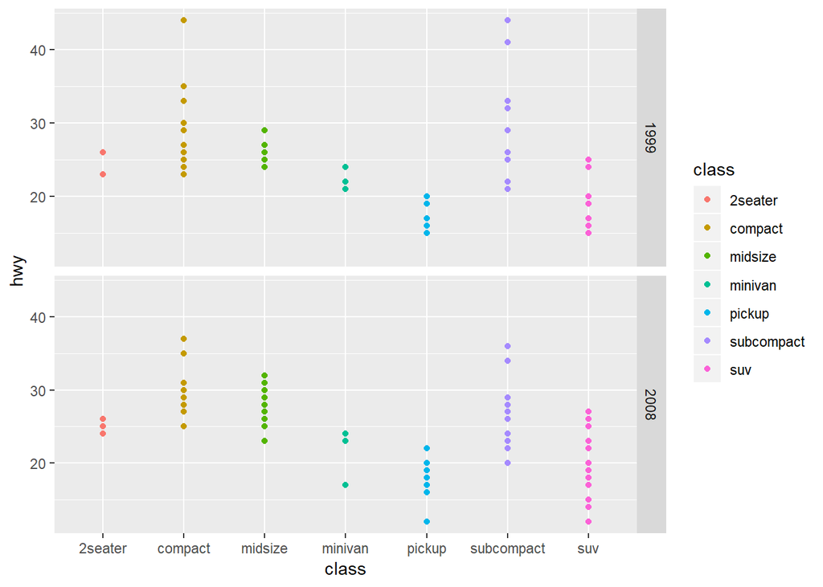

```r
# CODE GOES HERE
ggplot(data = mpg) + geom_point(mapping = aes(x = class, y = hwy,color=class)) + facet_wrap(vars(year), nrow = 2,strip.position="right" )
```

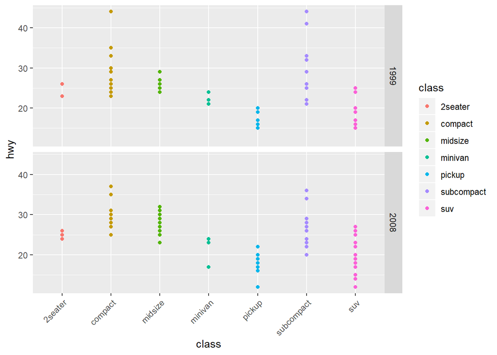

```r
# CODE GOES HERE
 p <- ggplot(data = mpg) + geom_point(mapping = aes(x = class, y = hwy,color=class)) + facet_wrap(vars(year), nrow = 2,strip.position="right" )
p+theme(axis.text.x = element_text(angle = 45, vjust = 1, hjust=1))
```

```r
#https://stackoverflow.com/questions/1330989/rotating-and-spacing-axis-labels-in-ggplot2
```

7. Many manufacturers are missing because the shape palette can deal with a maximum of 6 discrete values and the data points of the rest 9 categories are not displayed.In addition, 112 rows containing missing values are removed.

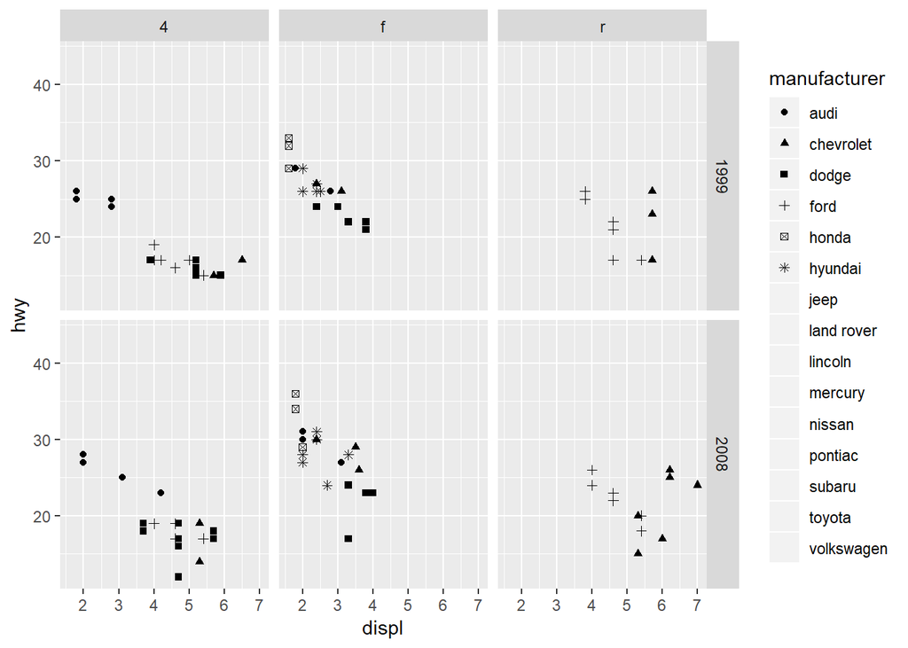

```r
# CODE GOES HERE
ggplot(data = mpg) + geom_point(mapping = aes(x = displ, y = hwy,shape= manufacturer)) + facet_grid(rows = vars(year), cols = vars(drv))
```

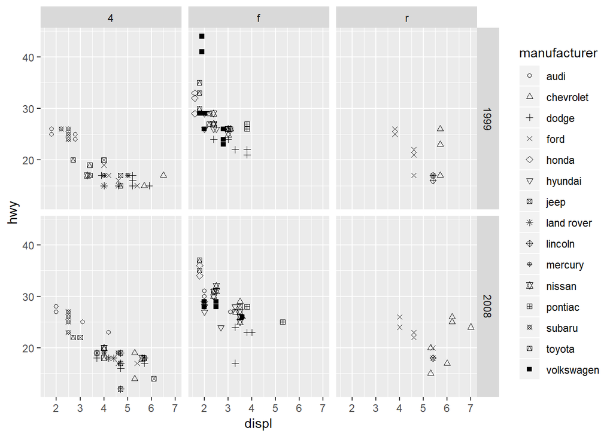

```r
# CODE GOES HERE
ggplot(data = mpg) + geom_point(mapping = aes(x = displ, y = hwy,shape= manufacturer)) + facet_grid(rows = vars(year), cols = vars(drv)) +scale_shape_manual(values = 1:15)
```

```r
#https://stackoverflow.com/questions/26223857/more-than-six-shapes-in-ggplot
```